# Bay of Biscay and the Iberian Coast

## South-Iberian Atlantic

### Summary

#### Table 1

**Table 1. Values of pressure and impact indicators for 2017-2022 for three depth strata in the South-Iberian Atlantic area. Values of I-1, I-2, I-3, I-4, I-6a, I-6b, I-7a and I-7b are annual means and I-5 is evaluated over the six years. Descriptions of the pressure and impact indicators are provided in the ‘Essential Information’ Table E1 in this document.**

| Indicators | 0 to 200 m | 200 to 400 m | 400 m to 800 m |
| --- | --- | --- | --- |
| Average fishing intensity (I-1) | 0.15 | 1.02 | 0.56 |
| Proportion of fished c-squares (I-2) | 0.27 | 0.55 | 0.61 |
| Proportion of area fished (I-3) | 0.11 | 0.29 | 0.24 |
| Smallest prop. of c-squares with 90% of total fishing intensity (I-4) | 0.13 | 0.20 | 0.21 |
| Proportion of persistently unfished c-squares (I-5) | 0.73 | 0.45 | 0.39 |
| Average PD impact (I-6a) | 0.01 | 0.04 | 0.03 |
| Average PD-sens impact (I-6b) | 0.01 | 0.04 | 0.03 |
| Proportion of c-squares with PD impact < 0.2 (I-7a) | 1.00 | 0.98 | 0.97 |
| Proportion of c-squares with PD-sens impact < 0.2 (I-7b) | 1.00 | 0.97 | 0.96 |

#### Figure 1

**Figure 1. Geographic distribution of fishing intensity (Swept Area Ratio), seabed sensitivity (community longevity), total landings value, and total landings weight from mobile bottom-contacting gear (MBCG) in the South-Iberian Atlantic area. The maps of swept area ratio, landings value, and landings weight show annual means.**

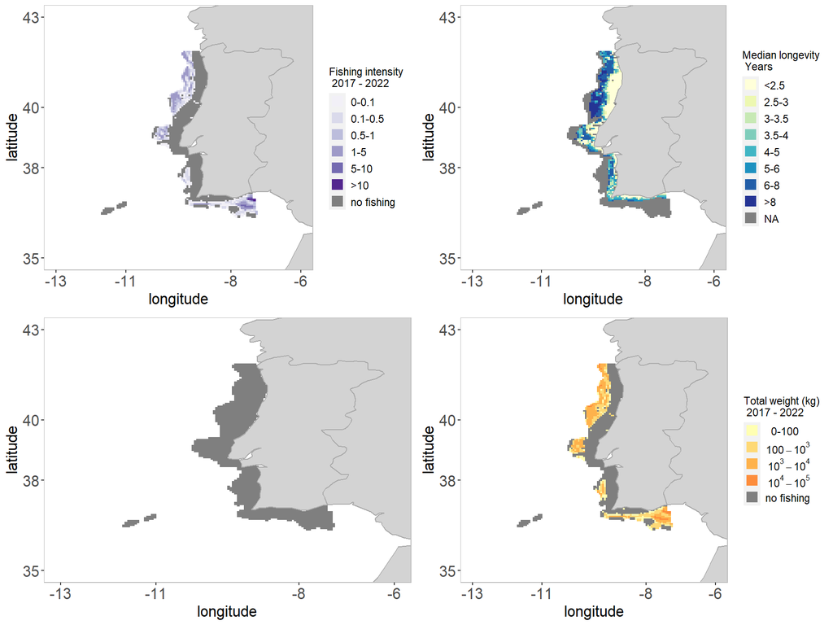

#### Table 2

**Table 2. Contribution of small-scale fisheries (vessels <12 m overall length) to total fishing effort (kW * fishing days) in the South-Iberian Atlantic area. The table shows the total fishing effort (kW * fishing days) by FAO region over the period 2017-2021, and the mean contribution (%), both mean and observed range of small-scale MBCG fisheries. This analysis is based on EU STECF Fisheries Dependent Information (FDI) effort data, which includes consistent information of SSF effort (while ICES VMS data does not). Please see the Main Advice for more information.**

| FAO region code | FAO region name | Total fishing effort (kW * Fishing days | Mean contribution SSF (%) | Observed range SSF contribution (%) [min - max] |
| --- | --- | --- | --- | --- |
| 27.9.a | Portuguese Waters - East | 7567817 | 23.17 | [2 - 34] |

### Fishing intensity

#### Table 3

**Table 3. Extent (in km<sup>2</sup> and %) of broad habitat types in the South-Iberian Atlantic area, and mean annual estimates of MBCG fishing intensity, landings weight, and landings value. In addition, estimates of the average annual proportion of the fished extent, the smallest proportion of the habitat extent affected by 90% of the fishing effort, and the proportion of unfished extent are provided.**

| MSFD broad habitat type | Extent of habitat (x1000 km<sup>2</sup>) | Relative habitat abundance (%) | Landings (x1000 tonnes) | Value (x10<sup>6</sup> euro) | Swept area (x1000 km<sup>2</sup>) | Average fishing intensity | Average annual extent fished (%) | Smallest proportion of extent with 90% of fishing effort | Percentage extent unfished (%) |
| --- | --- | --- | --- | --- | --- | --- | --- | --- | --- |
| Offshore circalittoral mud | 8.72 | 23.7 | 0.35 | 0 | 3.44 | 0.39 | 18 | 17.2 | 58.4 |
| Upper bathyal sediment or Upper bathyal rock and biogenic reef | 6.93 | 18.8 | 0.35 | 0 | 3.54 | 0.51 | 24 | 21.9 | 40.6 |
| Upper bathyal sediment | 6.04 | 16.4 | 0.58 | 0 | 5.07 | 0.84 | 32 | 25.3 | 35.6 |
| Circalittoral sand | 2.95 | 8.0 | 0.00 | 0 | 0.02 | 0.01 | 1 | 2.3 | 95.1 |
| Circalittoral mixed sediment | 2.49 | 6.8 | 0.00 | 0 | 0.02 | 0.01 | 1 | 2.7 | 90.9 |
| Offshore circalittoral sand | 2.26 | 6.1 | 0.18 | 0 | 1.09 | 0.48 | 33 | 33.4 | 46.3 |
| Offshore circalittoral rock and biogenic reef | 1.95 | 5.3 | 0.04 | 0 | 0.33 | 0.17 | 15 | 30.8 | 42.7 |
| Circalittoral mud | 1.77 | 4.8 | 0.00 | 0 | 0.02 | 0.01 | 1 | 1.0 | 93.9 |
| Circalittoral rock and biogenic reef | 1.64 | 4.4 | 0.00 | 0 | 0.02 | 0.01 | 1 | 3.2 | 93.5 |
| Offshore circalittoral mixed sediment | 0.64 | 1.7 | 0.02 | 0 | 0.22 | 0.34 | 8 | 6.7 | 70.5 |
| Infralittoral sand | 0.62 | 1.7 | 0.00 | 0 | 0.00 | 0.00 | 0 | 0.0 | 99.9 |
| Upper bathyal rock and biogenic reef | 0.24 | 0.7 | 0.00 | 0 | 0.03 | 0.10 | 9 | 19.8 | 67.6 |
| Infralittoral rock and biogenic reef | 0.21 | 0.6 | 0.00 | 0 | 0.00 | 0.00 | 0 | 0.0 | 99.8 |
| Unknown | 0.15 | 0.4 | 0.00 | 0 | 0.01 | 0.06 | 5 | 4.9 | 94.0 |
| Lower bathyal sediment or Lower bathyal rock and biogenic reef | 0.10 | 0.3 | 0.00 | 0 | 0.01 | 0.12 | 12 | 27.7 | 32.0 |
| Infralittoral mixed sediment | 0.06 | 0.2 | 0.00 | 0 | 0.00 | 0.00 | 0 | 0.0 | 97.5 |
| Offshore circalittoral coarse sediment | 0.05 | 0.1 | 0.00 | 0 | 0.00 | 0.09 | 9 | 5.3 | 87.2 |
| Infralittoral mud | 0.05 | 0.1 | 0.00 | 0 | 0.00 | 0.00 | 0 | 0.0 | 97.6 |
| Abyssal | 0.00 | 0.0 | 0.00 | 0 | 0.00 | 0.00 | 0 | NA | 58.3 |
| Circalittoral coarse sediment | 0.00 | 0.0 | 0.00 | 0 | 0.00 | 0.00 | 0 | NA | 100.0 |
| Lower bathyal sediment | 0.00 | 0.0 | 0.00 | 0 | 0.00 | 0.00 | 0 | NA | 100.0 |

#### Figure 2

**Figure 2. Temporal variation of the pressure indicators I-1, I-3 and I-4 in the South-Iberian Atlantic area. Descriptions of the pressure indicators are provided in the ‘Essential Information’ Table E1 in this document.**

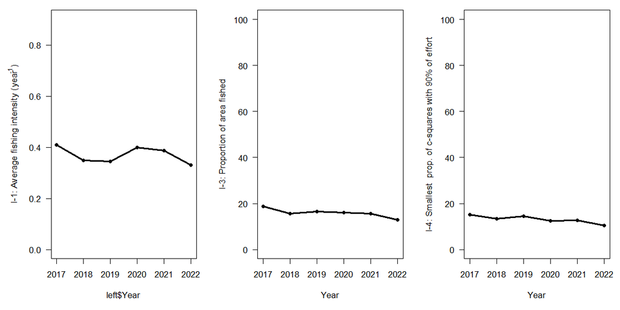

### Core fishing grounds

#### Figure 3

**Figure 3. Spatial stability of core MBCG fishing grounds, presented as the number of years a csquare is identified as a core fishing ground (smallest area responsible for 90% of the landings value) per métier for the South-Iberian Atlantic area. Only métiers that were active within >50 unique c-squares during the period 2017-2022 are included. The numbers between brackets show the proportion of fished extent compared to the overall assessed area extent.**

[figure not shown]

#### Figure 4

**Figure 4. Spatial distribution of the stability of the core MBCG fishing grounds, presented as the number of years a csquare is identified as a core fishing ground (smallest area responsible for 90% of the landings value) per métier for the South-Iberian Atlantic area. Only métiers that were active within >50 unique c-squares during the period 2017-2022 are included.**

[figure not shown]

### Fishing by métier

#### Table 4

**Table 4. Landings weight and value by métier and their relationship with swept area in the South-Iberian Atlantic area.**

|  | OT_CRU | OT_DMF | OT_MI |
| --- | --- | --- | --- |
| Area swept (1000 km2) | 7.80 | 5.94 | 0.09 |
| Landings (1000 tonnes) | 0.60 | 0.88 | 0.06 |
| Value (Million euro) | 0.00 | 0.00 | 0.00 |
| Landings / Area swept | 0.08 | 0.15 | 0.67 |
| Value / Area swept | 0.00 | 0.00 | 0.00 |

### Impact

#### Figure 5

**Figure 5. The spatial distribution of MBCG fisheries impact in the South-Iberian Atlantic area, as assessed with the PD indicator (I-6a) and PD-sens indicator (I-6b), shown as annual means for 2017-2022. Descriptions of the impact indicators are provided in the ‘Essential Information’ Table E1 in this document.**

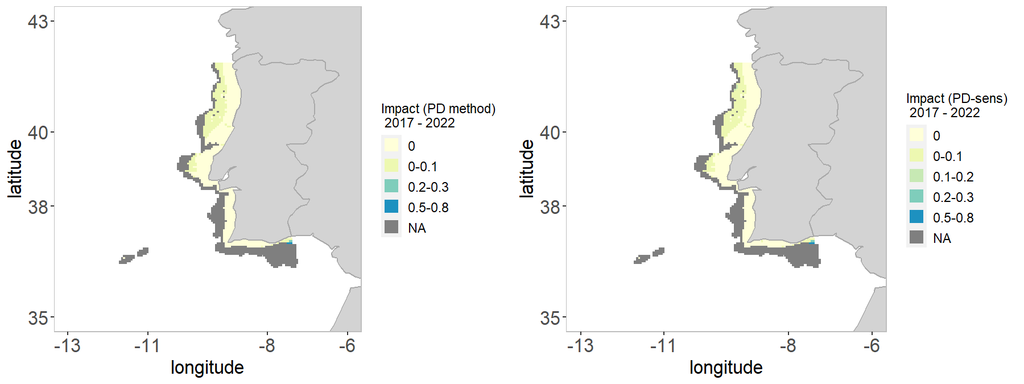

#### Figure 6

**Figure 6. Temporal variation in values of the PD indicator (I-6a), PD-sens indicator (I-6b), proportion of area with PD impact < 0.2 (I-7a) and proportion of area with PD-sens impact < 0.2 (I-7b), shown for the overall area and for the four most extensive broad habitat types separately in the South-Iberian Atlantic area. Descriptions of the impact indicators are provided in the ‘Essential Information’ Table E1 in this document.**

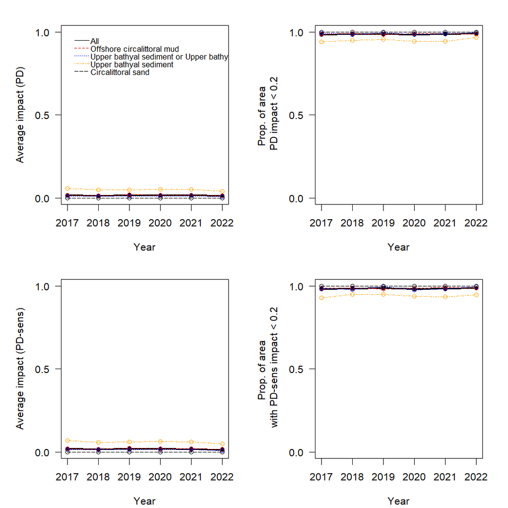

#### Table 5

**Table 5. Métier-specific landings weight and value per unit PD or PD-sens impact in the South-Iberian Atlantic area.**

|  | OT_CRU | OT_DMF | OT_MI |
| --- | --- | --- | --- |
| Landings (1000 tonnes)/PD impact | 0.007 | 0.029 | 0.030 |
| Value (million euro)/PD impact | 0.000 | 0.000 | 0.000 |
| Landings (1000 tonnes)/PD-sens impact | 0.007 | 0.028 | 0.028 |
| Value (million euro)/PD-sens impact | 0.000 | 0.000 | 0.000 |

#### Figure 7

**Figure 7. Métier-related impacts, as measured with the PD indicator (top) and PD-sens indicator (bottom), on the four most extensive broad habitat types in the South-Iberian Atlantic area.**

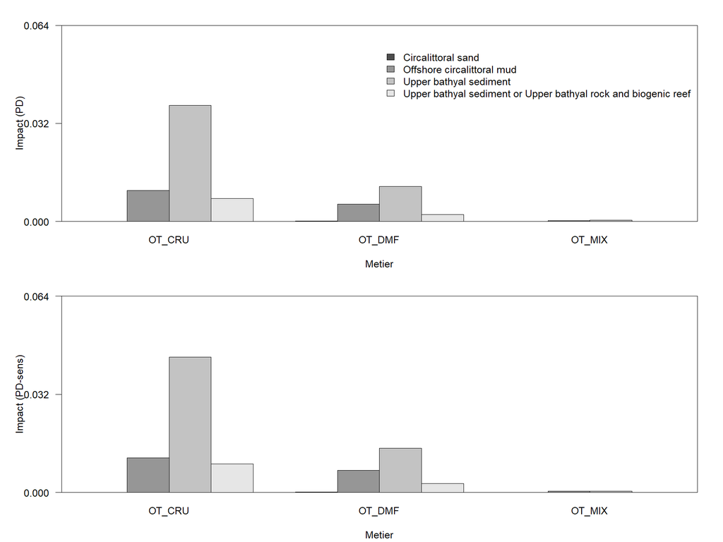

### Scenarios

#### Footprint reduction

##### Table 6: Effort

**Table 6. The effects of stepwise exclusion of all MBCG fisheries from a specified proportion of a MSFD broad habitat type within the South-Iberian Atlantic area, on swept area (presented as % of total swept area within that habitat type). The stepwise exclusion is conducted in 10% increments, and within each successive increment from 10% to 90% the c-squares with the lowest recorded rank MBCG swept area are excluded.**

| MSFD broad habitat type | Extent of habitat (x1000 km<sup>2</sup>) | Total area swept (x1000 km<sup>2</sup> | 0.1 | 0.2 | 0.3 | 0.4 | 0.5 | 0.6 | 0.7 | 0.8 | 0.9 |
| --- | --- | --- | --- | --- | --- | --- | --- | --- | --- | --- | --- |
| Offshore circalittoral mud | 8.72 | 3.44 | 0.0 | 0.0 | 0.0 | 0.0 | 0.0 | <0.1 | 1.7 | 7.2 | 23.9 |
| Upper bathyal sediment or Upper bathyal rock and biogenic reef | 6.93 | 3.54 | 0.0 | 0.0 | 0.0 | 0.0 | 0.2 | 1.3 | 4.9 | 12.0 | 32.1 |
| Upper bathyal sediment | 6.04 | 5.07 | 0.0 | 0.0 | 0.0 | <0.1 | 0.6 | 2.4 | 6.7 | 15.8 | 34.2 |
| Circalittoral sand | 2.95 | 0.02 | 0.0 | 0.0 | 0.0 | 0.0 | 0.0 | 0.0 | 0.0 | 0.0 | 0.0 |
| Circalittoral mixed sediment | 2.49 | 0.02 | 0.0 | 0.0 | 0.0 | 0.0 | 0.0 | 0.0 | 0.0 | 0.0 | 0.0 |
| Offshore circalittoral sand | 2.26 | 1.09 | 0.0 | 0.0 | 0.0 | 0.0 | 0.3 | 4.0 | 14.1 | 33.9 | 58.5 |
| Offshore circalittoral rock and biogenic reef | 1.95 | 0.33 | 0.0 | 0.0 | 0.0 | 0.0 | 0.8 | 4.6 | 11.5 | 22.8 | 46.0 |
| Circalittoral mud | 1.77 | 0.02 | 0.0 | 0.0 | 0.0 | 0.0 | 0.0 | 0.0 | 0.0 | 0.0 | 0.0 |
| Circalittoral rock and biogenic reef | 1.64 | 0.02 | 0.0 | 0.0 | 0.0 | 0.0 | 0.0 | 0.0 | 0.0 | 0.0 | 0.0 |
| Offshore circalittoral mixed sediment | 0.64 | 0.22 | 0.0 | 0.0 | 0.0 | 0.0 | 0.0 | 0.0 | 0.0 | 0.8 | 7.4 |
| Infralittoral sand | 0.62 | 0 | 0.0 | 0.0 | 0.0 | 0.0 | 0.0 | 0.0 | 0.0 | 0.0 | 0.0 |
| Upper bathyal rock and biogenic reef | 0.24 | 0.03 | 0.0 | 0.0 | 0.0 | 0.0 | 0.0 | 0.0 | 0.3 | 10.9 | 54.8 |
| Infralittoral rock and biogenic reef | 0.21 | 0 | 0.0 | 0.0 | 0.0 | 0.0 | 0.0 | 0.0 | 0.0 | 0.0 | 0.0 |
| Unknown | 0.15 | 0.01 | 0.0 | 0.0 | 0.0 | 0.0 | 0.0 | 0.0 | 0.0 | 0.0 | 0.0 |
| Lower bathyal sediment or Lower bathyal rock and biogenic reef | 0.1 | 0.01 | 0.0 | 0.0 | 0.0 | 3.5 | 6.5 | 6.5 | 10.4 | 41.9 | 78.9 |
| Infralittoral mixed sediment | 0.06 | 0 | 0.0 | 0.0 | 0.0 | 0.0 | 0.0 | 0.0 | 0.0 | 0.0 | 0.0 |
| Offshore circalittoral coarse sediment | 0.05 | 0 | 0.0 | 0.0 | 0.0 | 0.0 | 0.0 | 0.0 | 0.0 | 0.0 | 34.5 |
| Infralittoral mud | 0.05 | 0 | 0.0 | 0.0 | 0.0 | 0.0 | 0.0 | 0.0 | 0.0 | 0.0 | 0.0 |
| Abyssal | 0 | 0 | 0.0 | 0.0 | 0.0 | 0.0 | 0.0 | 100.0 | 100.0 | 100.0 | 100.0 |
| Circalittoral coarse sediment | 0 | 0 | NaN | NaN | NaN | NaN | NaN | NaN | NaN | NaN | NaN |
| Lower bathyal sediment | 0 | 0 | NaN | NaN | NaN | NaN | NaN | NaN | NaN | NaN | NaN |

##### Table 7: Landings value

**Table 7. The effects of stepwise exclusion of all MBCG fisheries from a specified proportion of a MSFD broad habitat type within the South-Iberian Atlantic area, on landings value (in 10<sup>6</sup> euro). The stepwise exclusion is conducted in 10% increments, and within each successive increment from 10% to 90% the c-squares with the lowest recorded rank MBCG swept area are excluded. Note that the top row shows the total estimate for all habitats combined.**

| MSFD broad habitat type | Extent of habitat (x1000 km<sup>2</sup>) | 0.1 | 0.2 | 0.3 | 0.4 | 0.5 | 0.6 | 0.7 | 0.8 | 0.9 |
| --- | --- | --- | --- | --- | --- | --- | --- | --- | --- | --- |
| Total | 36.86 | 0.0 | 0.0 | 0.0 | 0.0 | 0.0 | 0.0 | 0.0 | 0.0 | 0.0 |
| Offshore circalittoral mud | 8.72 | 0.0 | 0.0 | 0.0 | 0.0 | 0.0 | 0.0 | 0.0 | 0.0 | 0.0 |
| Upper bathyal sediment or Upper bathyal rock and biogenic reef | 6.93 | 0.0 | 0.0 | 0.0 | 0.0 | 0.0 | 0.0 | 0.0 | 0.0 | 0.0 |
| Upper bathyal sediment | 6.04 | 0.0 | 0.0 | 0.0 | 0.0 | 0.0 | 0.0 | 0.0 | 0.0 | 0.0 |
| Circalittoral sand | 2.95 | 0.0 | 0.0 | 0.0 | 0.0 | 0.0 | 0.0 | 0.0 | 0.0 | 0.0 |
| Circalittoral mixed sediment | 2.49 | 0.0 | 0.0 | 0.0 | 0.0 | 0.0 | 0.0 | 0.0 | 0.0 | 0.0 |
| Offshore circalittoral sand | 2.26 | 0.0 | 0.0 | 0.0 | 0.0 | 0.0 | 0.0 | 0.0 | 0.0 | 0.0 |
| Offshore circalittoral rock and biogenic reef | 1.95 | 0.0 | 0.0 | 0.0 | 0.0 | 0.0 | 0.0 | 0.0 | 0.0 | 0.0 |
| Circalittoral mud | 1.77 | 0.0 | 0.0 | 0.0 | 0.0 | 0.0 | 0.0 | 0.0 | 0.0 | 0.0 |
| Circalittoral rock and biogenic reef | 1.64 | 0.0 | 0.0 | 0.0 | 0.0 | 0.0 | 0.0 | 0.0 | 0.0 | 0.0 |
| Offshore circalittoral mixed sediment | 0.64 | 0.0 | 0.0 | 0.0 | 0.0 | 0.0 | 0.0 | 0.0 | 0.0 | 0.0 |
| Infralittoral sand | 0.62 | 0.0 | 0.0 | 0.0 | 0.0 | 0.0 | 0.0 | 0.0 | 0.0 | 0.0 |
| Upper bathyal rock and biogenic reef | 0.24 | 0.0 | 0.0 | 0.0 | 0.0 | 0.0 | 0.0 | 0.0 | 0.0 | 0.0 |
| Infralittoral rock and biogenic reef | 0.21 | 0.0 | 0.0 | 0.0 | 0.0 | 0.0 | 0.0 | 0.0 | 0.0 | 0.0 |
| Unknown | 0.15 | 0.0 | 0.0 | 0.0 | 0.0 | 0.0 | 0.0 | 0.0 | 0.0 | 0.0 |
| Lower bathyal sediment or Lower bathyal rock and biogenic reef | 0.1 | 0.0 | 0.0 | 0.0 | 0.0 | 0.0 | 0.0 | 0.0 | 0.0 | 0.0 |
| Infralittoral mixed sediment | 0.06 | 0.0 | 0.0 | 0.0 | 0.0 | 0.0 | 0.0 | 0.0 | 0.0 | 0.0 |
| Offshore circalittoral coarse sediment | 0.05 | 0.0 | 0.0 | 0.0 | 0.0 | 0.0 | 0.0 | 0.0 | 0.0 | 0.0 |
| Infralittoral mud | 0.05 | 0.0 | 0.0 | 0.0 | 0.0 | 0.0 | 0.0 | 0.0 | 0.0 | 0.0 |
| Abyssal | 0 | 0.0 | 0.0 | 0.0 | 0.0 | 0.0 | 0.0 | 0.0 | 0.0 | 0.0 |
| Circalittoral coarse sediment | 0 | 0.0 | 0.0 | 0.0 | 0.0 | 0.0 | 0.0 | 0.0 | 0.0 | 0.0 |
| Lower bathyal sediment | 0 | 0.0 | 0.0 | 0.0 | 0.0 | 0.0 | 0.0 | 0.0 | 0.0 | 0.0 |

##### Table 8: Landings weight

**Table 8. The effects of stepwise exclusion of all MBCG fisheries from a specified proportion of a MSFD broad habitat type within the South-Iberian Atlantic area, on landings weight (in 10<sup>6</sup> kg). The stepwise exclusion is conducted in 10% increments, and within each successive increment from 10% to 90% the c-squares with the lowest recorded rank MBCG swept area are excluded. Note that the top row shows the total estimate for all habitats combined.**

| MSFD broad habitat type | Extent of habitat (x1000 km<sup>2</sup>) | 0.1 | 0.2 | 0.3 | 0.4 | 0.5 | 0.6 | 0.7 | 0.8 | 0.9 |
| --- | --- | --- | --- | --- | --- | --- | --- | --- | --- | --- |
| Total | 36.86 | 0.0 | 0.0 | 0.0 | <0.1 | <0.1 | <0.1 | <0.1 | 0.2 | 0.6 |
| Offshore circalittoral mud | 8.72 | 0.0 | 0.0 | 0.0 | 0.0 | 0.0 | <0.1 | <0.1 | <0.1 | 0.1 |
| Upper bathyal sediment or Upper bathyal rock and biogenic reef | 6.93 | 0.0 | 0.0 | 0.0 | 0.0 | <0.1 | <0.1 | <0.1 | <0.1 | 0.1 |
| Upper bathyal sediment | 6.04 | 0.0 | 0.0 | 0.0 | <0.1 | <0.1 | <0.1 | <0.1 | <0.1 | 0.2 |
| Circalittoral sand | 2.95 | 0.0 | 0.0 | 0.0 | 0.0 | 0.0 | 0.0 | 0.0 | 0.0 | 0.0 |
| Circalittoral mixed sediment | 2.49 | 0.0 | 0.0 | 0.0 | 0.0 | 0.0 | 0.0 | 0.0 | 0.0 | 0.0 |
| Offshore circalittoral sand | 2.26 | 0.0 | 0.0 | 0.0 | 0.0 | <0.1 | <0.1 | <0.1 | <0.1 | <0.1 |
| Offshore circalittoral rock and biogenic reef | 1.95 | 0.0 | 0.0 | 0.0 | 0.0 | <0.1 | <0.1 | <0.1 | <0.1 | <0.1 |
| Circalittoral mud | 1.77 | 0.0 | 0.0 | 0.0 | 0.0 | 0.0 | 0.0 | 0.0 | 0.0 | 0.0 |
| Circalittoral rock and biogenic reef | 1.64 | 0.0 | 0.0 | 0.0 | 0.0 | 0.0 | 0.0 | 0.0 | 0.0 | 0.0 |
| Offshore circalittoral mixed sediment | 0.64 | 0.0 | 0.0 | 0.0 | 0.0 | 0.0 | 0.0 | 0.0 | <0.1 | <0.1 |
| Infralittoral sand | 0.62 | 0.0 | 0.0 | 0.0 | 0.0 | 0.0 | 0.0 | 0.0 | 0.0 | 0.0 |
| Upper bathyal rock and biogenic reef | 0.24 | 0.0 | 0.0 | 0.0 | 0.0 | 0.0 | 0.0 | <0.1 | <0.1 | <0.1 |
| Infralittoral rock and biogenic reef | 0.21 | 0.0 | 0.0 | 0.0 | 0.0 | 0.0 | 0.0 | 0.0 | 0.0 | 0.0 |
| Unknown | 0.15 | 0.0 | 0.0 | 0.0 | 0.0 | 0.0 | 0.0 | 0.0 | 0.0 | 0.0 |
| Lower bathyal sediment or Lower bathyal rock and biogenic reef | 0.1 | 0.0 | 0.0 | 0.0 | <0.1 | <0.1 | <0.1 | <0.1 | <0.1 | <0.1 |
| Infralittoral mixed sediment | 0.06 | 0.0 | 0.0 | 0.0 | 0.0 | 0.0 | 0.0 | 0.0 | 0.0 | 0.0 |
| Offshore circalittoral coarse sediment | 0.05 | 0.0 | 0.0 | 0.0 | 0.0 | 0.0 | 0.0 | 0.0 | 0.0 | <0.1 |
| Infralittoral mud | 0.05 | 0.0 | 0.0 | 0.0 | 0.0 | 0.0 | 0.0 | 0.0 | 0.0 | 0.0 |
| Abyssal | 0 | 0.0 | 0.0 | 0.0 | 0.0 | 0.0 | <0.1 | <0.1 | <0.1 | <0.1 |
| Circalittoral coarse sediment | 0 | 0.0 | 0.0 | 0.0 | 0.0 | 0.0 | 0.0 | 0.0 | 0.0 | 0.0 |
| Lower bathyal sediment | 0 | 0.0 | 0.0 | 0.0 | 0.0 | 0.0 | 0.0 | 0.0 | 0.0 | 0.0 |

#### Gear modifications

##### Figure 8: Habitat 1

**Figure 8. Effects of gear modifications (5%, 10%, and 20% lower depletion) on the quality-quantity threshold for the most abundant MSFD habitat type in the South-Iberian Atlantic area. Habitat quality is defined as 1 - impact, with impact calculated as PD (I-6a) or PD-sens (I-7a). The dotted line represent the extent threshold of 75%.**

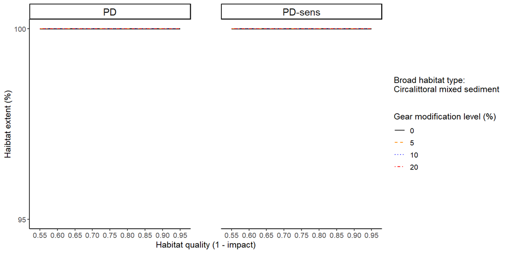

##### Figure 9: Habitat 2

**Figure 9. Effects of gear modifications (5%, 10%, and 20% lower depletion) on the quality-quantity threshold for the most abundant MSFD habitat type in the South-Iberian Atlantic area. Habitat quality is defined as 1 - impact, with impact calculated as PD (I-6a) or PD-sens (I-7a). The dotted line represent the extent threshold of 75%.**

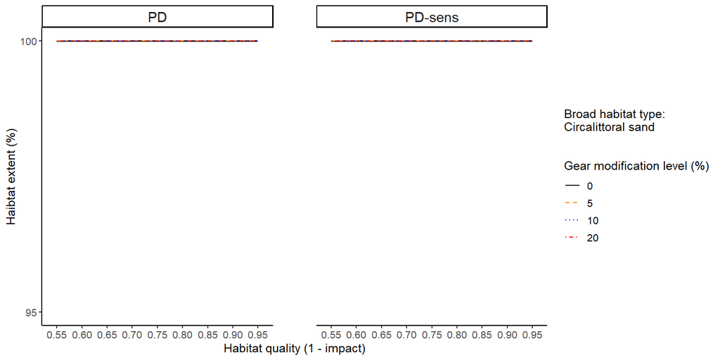

##### Figure 10: Habitat 3

**Figure 10. Effects of gear modifications (5%, 10%, and 20% lower depletion) on the quality-quantity threshold for the most abundant MSFD habitat type in the South-Iberian Atlantic area. Habitat quality is defined as 1 - impact, with impact calculated as PD (I-6a) or PD-sens (I-7a). The dotted line represent the extent threshold of 75%.**

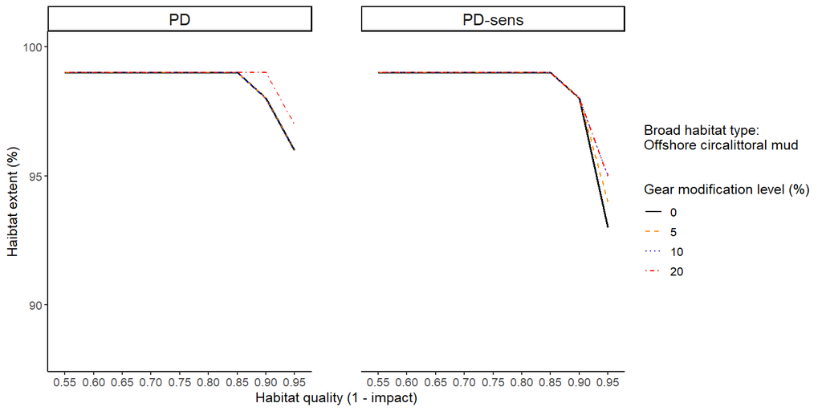

##### Figure 11: Habitat 4

**Figure 11. Effects of gear modifications (5%, 10%, and 20% lower depletion) on the quality-quantity threshold for the most abundant MSFD habitat type in the South-Iberian Atlantic area. Habitat quality is defined as 1 - impact, with impact calculated as PD (I-6a) or PD-sens (I-7a). The dotted line represent the extent threshold of 75%.**

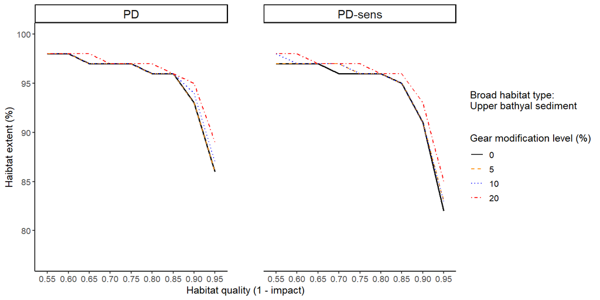

## Gulf of Cadiz

### Summary

#### Table 1

**Table 1. Values of pressure and impact indicators for 2017-2022 for three depth strata in the Gulf of Cadiz area. Values of I-1, I-2, I-3, I-4, I-6a, I-6b, I-7a and I-7b are annual means and I-5 is evaluated over the six years. Descriptions of the pressure and impact indicators are provided in the ‘Essential Information’ Table E1 in this document.**

| Indicators | 0 to 200 m | 200 to 400 m | 400 m to 800 m |
| --- | --- | --- | --- |
| Average fishing intensity (I-1) | 8.51 | 9.00 | 1.06 |
| Proportion of fished c-squares (I-2) | 0.85 | 1.00 | 0.53 |
| Proportion of area fished (I-3) | 0.68 | 0.91 | 0.39 |
| Smallest prop. of c-squares with 90% of total fishing intensity (I-4) | 0.40 | 0.49 | 0.29 |
| Proportion of persistently unfished c-squares (I-5) | 0.15 | 0.00 | 0.47 |
| Average PD impact (I-6a) | 0.37 | 0.47 | 0.12 |
| Average PD-sens impact (I-6b) | 0.40 | 0.52 | 0.15 |
| Proportion of c-squares with PD impact < 0.2 (I-7a) | 0.50 | 0.33 | 0.79 |
| Proportion of c-squares with PD-sens impact < 0.2 (I-7b) | 0.51 | 0.30 | 0.74 |

#### Figure 1

**Figure 1. Geographic distribution of fishing intensity (Swept Area Ratio), seabed sensitivity (community longevity), total landings value, and total landings weight from mobile bottom-contacting gear (MBCG) in the Gulf of Cadiz area. The maps of swept area ratio, landings value, and landings weight show annual means.**

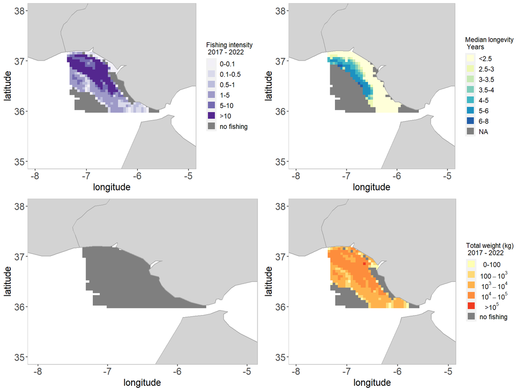

#### Table 2

**Table 2. Contribution of small-scale fisheries (vessels <12 m overall length) to total fishing effort (kW * fishing days) in the Gulf of Cadiz area. The table shows the total fishing effort (kW * fishing days) by FAO region over the period 2017-2021, and the mean contribution (%), both mean and observed range of small-scale MBCG fisheries. This analysis is based on EU STECF Fisheries Dependent Information (FDI) effort data, which includes consistent information of SSF effort (while ICES VMS data does not). Please see the Main Advice for more information.**

| FAO region code | FAO region name | Total fishing effort (kW * Fishing days | Mean contribution SSF (%) | Observed range SSF contribution (%) [min - max] |
| --- | --- | --- | --- | --- |
| 27.9.a | Portuguese Waters - East | 7567817 | 23.17 | [2 - 34] |

### Fishing intensity

#### Table 3

**Table 3. Extent (in km<sup>2</sup> and %) of broad habitat types in the Gulf of Cadiz area, and mean annual estimates of MBCG fishing intensity, landings weight, and landings value. In addition, estimates of the average annual proportion of the fished extent, the smallest proportion of the habitat extent affected by 90% of the fishing effort, and the proportion of unfished extent are provided.**

| MSFD broad habitat type | Extent of habitat (x1000 km<sup>2</sup>) | Relative habitat abundance (%) | Landings (x1000 tonnes) | Value (x10<sup>6</sup> euro) | Swept area (x1000 km<sup>2</sup>) | Average fishing intensity | Average annual extent fished (%) | Smallest proportion of extent with 90% of fishing effort | Percentage extent unfished (%) |
| --- | --- | --- | --- | --- | --- | --- | --- | --- | --- |
| Upper bathyal sediment | 4.08 | 37.0 | 0.96 | 0 | 11.62 | 2.85 | 52 | 33.4 | 35.6 |
| Circalittoral sand | 1.79 | 16.3 | 0.80 | 0 | 10.51 | 5.87 | 60 | 34.0 | 19.2 |
| Circalittoral mud | 1.72 | 15.6 | 1.71 | 0 | 25.68 | 14.95 | 89 | 65.8 | 2.6 |
| Offshore circalittoral mud | 1.28 | 11.6 | 1.45 | 0 | 20.81 | 16.28 | 100 | 77.1 | 0.0 |
| Offshore circalittoral sand | 0.57 | 5.2 | 0.08 | 0 | 0.94 | 1.65 | 86 | 72.8 | 0.0 |
| Infralittoral sand | 0.44 | 4.0 | 0.07 | 0 | 0.63 | 1.44 | 18 | 6.5 | 37.6 |
| Circalittoral mixed sediment | 0.15 | 1.3 | 0.14 | 0 | 1.64 | 11.24 | 93 | 52.9 | 0.6 |
| Infralittoral rock and biogenic reef | 0.14 | 1.3 | 0.00 | 0 | 0.01 | 0.05 | 5 | 9.2 | 89.1 |
| Circalittoral rock and biogenic reef | 0.13 | 1.2 | 0.01 | 0 | 0.05 | 0.38 | 19 | 20.5 | 61.1 |
| Infralittoral mixed sediment | 0.13 | 1.2 | 0.02 | 0 | 0.20 | 1.53 | 33 | 20.8 | 2.3 |
| Upper bathyal rock and biogenic reef | 0.12 | 1.1 | 0.01 | 0 | 0.09 | 0.70 | 35 | 30.1 | 39.0 |
| Infralittoral mud | 0.12 | 1.1 | 0.02 | 0 | 0.04 | 0.37 | 9 | 5.5 | 33.7 |
| Infralittoral coarse sediment | 0.10 | 0.9 | 0.02 | 0 | 0.10 | 0.97 | 32 | 25.4 | 21.3 |
| Circalittoral coarse sediment | 0.10 | 0.9 | 0.03 | 0 | 0.27 | 2.70 | 77 | 61.6 | 5.1 |
| Offshore circalittoral coarse sediment | 0.08 | 0.7 | 0.02 | 0 | 0.25 | 3.10 | 66 | 40.3 | 0.0 |
| Offshore circalittoral mixed sediment | 0.06 | 0.5 | 0.10 | 0 | 1.44 | 25.28 | 100 | 83.8 | 0.0 |
| Unknown | 0.00 | 0.0 | 0.00 | 0 | 0.00 | 0.01 | 1 | NA | 61.3 |

#### Figure 2

**Figure 2. Temporal variation of the pressure indicators I-1, I-3 and I-4 in the Gulf of Cadiz area. Descriptions of the pressure indicators are provided in the ‘Essential Information’ Table E1 in this document.**

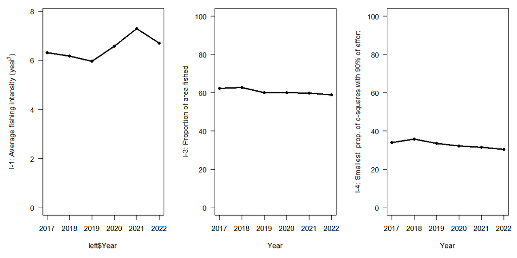

### Core fishing grounds

#### Figure 3

**Figure 3. Spatial stability of core MBCG fishing grounds, presented as the number of years a csquare is identified as a core fishing ground (smallest area responsible for 90% of the landings value) per métier for the Gulf of Cadiz area. Only métiers that were active within >50 unique c-squares during the period 2017-2022 are included. The numbers between brackets show the proportion of fished extent compared to the overall assessed area extent.**

[figure not shown]

#### Figure 4

**Figure 4. Spatial distribution of the stability of the core MBCG fishing grounds, presented as the number of years a csquare is identified as a core fishing ground (smallest area responsible for 90% of the landings value) per métier for the Gulf of Cadiz area. Only métiers that were active within >50 unique c-squares during the period 2017-2022 are included.**

[figure not shown]

### Fishing by métier

#### Table 4

**Table 4. Landings weight and value by métier and their relationship with swept area in the Gulf of Cadiz area.**

|  | DRB_MOL | OT_CRU | OT_DMF | OT_MI |
| --- | --- | --- | --- | --- |
| Area swept (1000 km2) | 0.02 | 73.14 | 0.79 | 0.39 |
| Landings (1000 tonnes) | 0.10 | 5.24 | 0.06 | 0.04 |
| Value (Million euro) | 0.00 | 0.00 | 0.00 | 0.00 |
| Landings / Area swept | 5.27 | 0.07 | 0.08 | 0.10 |
| Value / Area swept | 0.00 | 0.00 | 0.00 | 0.00 |

### Impact

#### Figure 5

**Figure 5. The spatial distribution of MBCG fisheries impact in the Gulf of Cadiz area, as assessed with the PD indicator (I-6a) and PD-sens indicator (I-6b), shown as annual means for 2017-2022. Descriptions of the impact indicators are provided in the ‘Essential Information’ Table E1 in this document.**

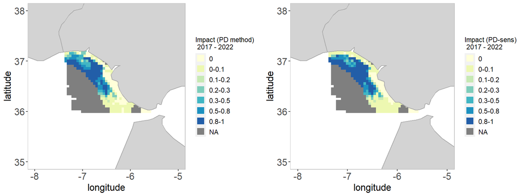

#### Figure 6

**Figure 6. Temporal variation in values of the PD indicator (I-6a), PD-sens indicator (I-6b), proportion of area with PD impact < 0.2 (I-7a) and proportion of area with PD-sens impact < 0.2 (I-7b), shown for the overall area and for the four most extensive broad habitat types separately in the Gulf of Cadiz area. Descriptions of the impact indicators are provided in the ‘Essential Information’ Table E1 in this document.**

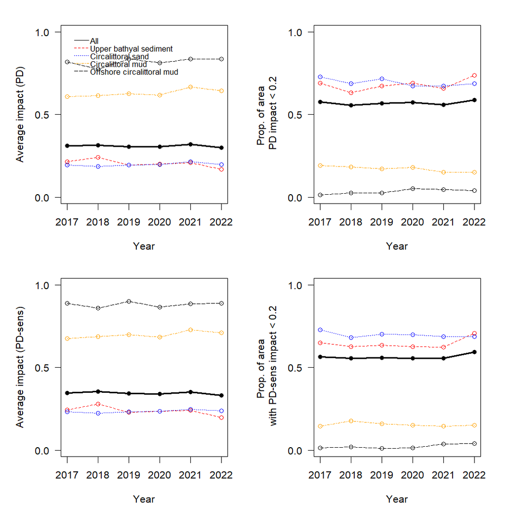

#### Table 5

**Table 5. Métier-specific landings weight and value per unit PD or PD-sens impact in the Gulf of Cadiz area.**

|  | DRB_MOL | OT_CRU | OT_DMF | OT_MI |
| --- | --- | --- | --- | --- |
| Landings (1000 tonnes)/PD impact | 0.037 | 0.036 | 0.058 | 0.060 |
| Value (million euro)/PD impact | 0.000 | 0.000 | 0.000 | 0.000 |
| Landings (1000 tonnes)/PD-sens impact | 0.048 | 0.032 | 0.045 | 0.063 |
| Value (million euro)/PD-sens impact | 0.000 | 0.000 | 0.000 | 0.000 |

#### Figure 7

**Figure 7. Métier-related impacts, as measured with the PD indicator (top) and PD-sens indicator (bottom), on the four most extensive broad habitat types in the Gulf of Cadiz area.**

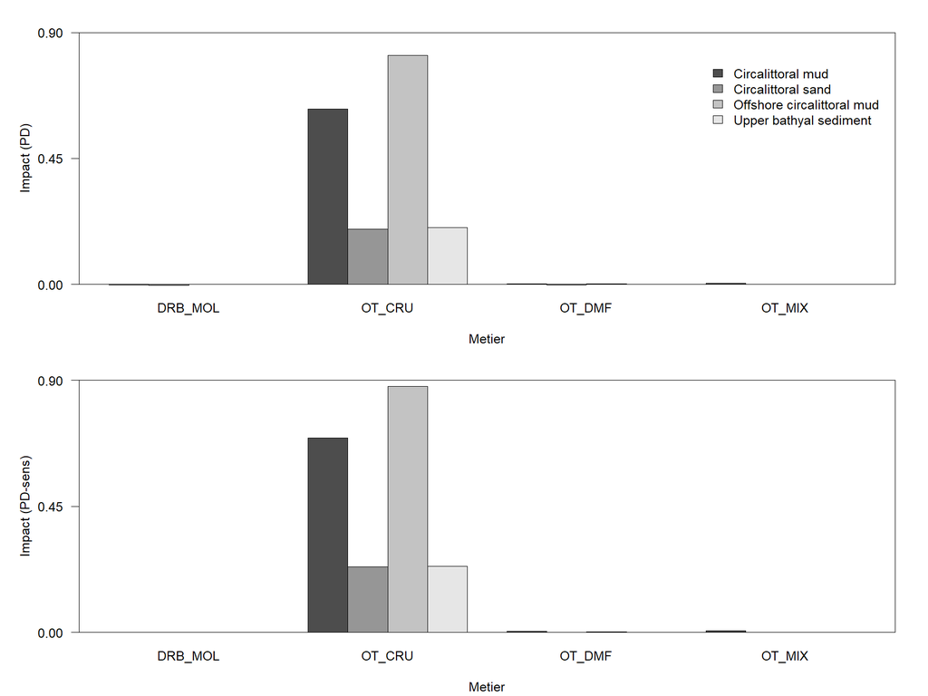

### Scenarios

#### Footprint reduction

##### Table 6: Effort

**Table 6. The effects of stepwise exclusion of all MBCG fisheries from a specified proportion of a MSFD broad habitat type within the Gulf of Cadiz area, on swept area (presented as % of total swept area within that habitat type). The stepwise exclusion is conducted in 10% increments, and within each successive increment from 10% to 90% the c-squares with the lowest recorded rank MBCG swept area are excluded.**

| MSFD broad habitat type | Extent of habitat (x1000 km<sup>2</sup>) | Total area swept (x1000 km<sup>2</sup> | 0.1 | 0.2 | 0.3 | 0.4 | 0.5 | 0.6 | 0.7 | 0.8 | 0.9 |
| --- | --- | --- | --- | --- | --- | --- | --- | --- | --- | --- | --- |
| Upper bathyal sediment | 4.08 | 11.62 | 0.0 | 0.0 | 0.0 | <0.1 | 1.4 | 5.5 | 13.0 | 23.2 | 41.2 |
| Circalittoral sand | 1.79 | 10.51 | 0.0 | <0.1 | <0.1 | 0.8 | 2.1 | 7.6 | 14.6 | 34.1 | 64.4 |
| Circalittoral mud | 1.72 | 25.68 | <0.1 | 3.6 | 9.2 | 14.6 | 20.9 | 31.3 | 42.2 | 54.9 | 72.0 |
| Offshore circalittoral mud | 1.28 | 20.81 | 3.4 | 8.5 | 14.3 | 21.9 | 29.8 | 41.4 | 55.2 | 66.8 | 83.2 |
| Offshore circalittoral sand | 0.57 | 0.94 | 2.2 | 7.6 | 13.0 | 20.4 | 28.3 | 37.8 | 48.8 | 61.8 | 78.0 |
| Infralittoral sand | 0.44 | 0.63 | 0.0 | 0.0 | 0.0 | <0.1 | <0.1 | 0.2 | 1.1 | 3.2 | 6.5 |
| Circalittoral mixed sediment | 0.15 | 1.64 | 1.3 | 3.4 | 6.5 | 9.1 | 16.0 | 27.3 | 50.3 | 73.4 | 100.0 |
| Infralittoral rock and biogenic reef | 0.14 | 0.01 | 0.0 | 0.0 | 0.0 | 0.0 | 0.0 | 0.0 | 0.0 | 0.0 | 9.1 |
| Circalittoral rock and biogenic reef | 0.13 | 0.05 | 0.0 | 0.0 | 0.0 | 0.0 | 0.0 | 0.0 | 2.7 | 16.4 | 55.8 |
| Infralittoral mixed sediment | 0.13 | 0.2 | <0.1 | <0.1 | <0.1 | <0.1 | 0.2 | 0.3 | 12.5 | 21.1 | 37.1 |
| Upper bathyal rock and biogenic reef | 0.12 | 0.09 | 0.0 | 0.0 | 0.0 | 0.2 | 1.7 | 7.1 | 16.5 | 65.8 | 86.6 |
| Infralittoral mud | 0.12 | 0.04 | 0.0 | 0.0 | 0.0 | <0.1 | <0.1 | 0.7 | 2.1 | 4.9 | 10.8 |
| Infralittoral coarse sediment | 0.1 | 0.1 | 0.0 | 0.0 | 0.1 | 0.1 | 0.4 | 0.9 | 3.1 | 40.2 | 40.2 |
| Circalittoral coarse sediment | 0.1 | 0.27 | <0.1 | 1.2 | 6.9 | 14.7 | 17.8 | 40.7 | 40.7 | 76.3 | 76.3 |
| Offshore circalittoral coarse sediment | 0.08 | 0.25 | 0.7 | 1.7 | 3.5 | 8.4 | 8.4 | 15.9 | 20.7 | 40.0 | 100.0 |
| Offshore circalittoral mixed sediment | 0.06 | 1.44 | 12.4 | 16.3 | 29.7 | 37.9 | 46.2 | 69.6 | 69.6 | 82.9 | 100.0 |
| Unknown | 0 | 0 | 0.0 | 0.0 | 0.0 | 0.0 | 0.0 | 0.0 | 33.1 | 33.1 | 33.1 |

##### Table 7: Landings value

**Table 7. The effects of stepwise exclusion of all MBCG fisheries from a specified proportion of a MSFD broad habitat type within the Gulf of Cadiz area, on landings value (in 10<sup>6</sup> euro). The stepwise exclusion is conducted in 10% increments, and within each successive increment from 10% to 90% the c-squares with the lowest recorded rank MBCG swept area are excluded. Note that the top row shows the total estimate for all habitats combined.**

| MSFD broad habitat type | Extent of habitat (x1000 km<sup>2</sup>) | 0.1 | 0.2 | 0.3 | 0.4 | 0.5 | 0.6 | 0.7 | 0.8 | 0.9 |
| --- | --- | --- | --- | --- | --- | --- | --- | --- | --- | --- |
| Total | 11.01 | 0.0 | 0.0 | 0.0 | 0.0 | 0.0 | 0.0 | 0.0 | 0.0 | 0.0 |
| Upper bathyal sediment | 4.08 | 0.0 | 0.0 | 0.0 | 0.0 | 0.0 | 0.0 | 0.0 | 0.0 | 0.0 |
| Circalittoral sand | 1.79 | 0.0 | 0.0 | 0.0 | 0.0 | 0.0 | 0.0 | 0.0 | 0.0 | 0.0 |
| Circalittoral mud | 1.72 | 0.0 | 0.0 | 0.0 | 0.0 | 0.0 | 0.0 | 0.0 | 0.0 | 0.0 |
| Offshore circalittoral mud | 1.28 | 0.0 | 0.0 | 0.0 | 0.0 | 0.0 | 0.0 | 0.0 | 0.0 | 0.0 |
| Offshore circalittoral sand | 0.57 | 0.0 | 0.0 | 0.0 | 0.0 | 0.0 | 0.0 | 0.0 | 0.0 | 0.0 |
| Infralittoral sand | 0.44 | 0.0 | 0.0 | 0.0 | 0.0 | 0.0 | 0.0 | 0.0 | 0.0 | 0.0 |
| Circalittoral mixed sediment | 0.15 | 0.0 | 0.0 | 0.0 | 0.0 | 0.0 | 0.0 | 0.0 | 0.0 | 0.0 |
| Infralittoral rock and biogenic reef | 0.14 | 0.0 | 0.0 | 0.0 | 0.0 | 0.0 | 0.0 | 0.0 | 0.0 | 0.0 |
| Circalittoral rock and biogenic reef | 0.13 | 0.0 | 0.0 | 0.0 | 0.0 | 0.0 | 0.0 | 0.0 | 0.0 | 0.0 |
| Infralittoral mixed sediment | 0.13 | 0.0 | 0.0 | 0.0 | 0.0 | 0.0 | 0.0 | 0.0 | 0.0 | 0.0 |
| Upper bathyal rock and biogenic reef | 0.12 | 0.0 | 0.0 | 0.0 | 0.0 | 0.0 | 0.0 | 0.0 | 0.0 | 0.0 |
| Infralittoral mud | 0.12 | 0.0 | 0.0 | 0.0 | 0.0 | 0.0 | 0.0 | 0.0 | 0.0 | 0.0 |
| Infralittoral coarse sediment | 0.1 | 0.0 | 0.0 | 0.0 | 0.0 | 0.0 | 0.0 | 0.0 | 0.0 | 0.0 |
| Circalittoral coarse sediment | 0.1 | 0.0 | 0.0 | 0.0 | 0.0 | 0.0 | 0.0 | 0.0 | 0.0 | 0.0 |
| Offshore circalittoral coarse sediment | 0.08 | 0.0 | 0.0 | 0.0 | 0.0 | 0.0 | 0.0 | 0.0 | 0.0 | 0.0 |
| Offshore circalittoral mixed sediment | 0.06 | 0.0 | 0.0 | 0.0 | 0.0 | 0.0 | 0.0 | 0.0 | 0.0 | 0.0 |
| Unknown | 0 | 0.0 | 0.0 | 0.0 | 0.0 | 0.0 | 0.0 | 0.0 | 0.0 | 0.0 |

##### Table 8: Landings weight

**Table 8. The effects of stepwise exclusion of all MBCG fisheries from a specified proportion of a MSFD broad habitat type within the Gulf of Cadiz area, on landings weight (in 10<sup>6</sup> kg). The stepwise exclusion is conducted in 10% increments, and within each successive increment from 10% to 90% the c-squares with the lowest recorded rank MBCG swept area are excluded. Note that the top row shows the total estimate for all habitats combined.**

| MSFD broad habitat type | Extent of habitat (x1000 km<sup>2</sup>) | 0.1 | 0.2 | 0.3 | 0.4 | 0.5 | 0.6 | 0.7 | 0.8 | 0.9 |
| --- | --- | --- | --- | --- | --- | --- | --- | --- | --- | --- |
| Total | 11.01 | <0.1 | 0.2 | 0.5 | 0.7 | 1.0 | 1.5 | 2.1 | 2.9 | 3.9 |
| Upper bathyal sediment | 4.08 | 0.0 | 0.0 | 0.0 | <0.1 | <0.1 | <0.1 | 0.1 | 0.2 | 0.4 |
| Circalittoral sand | 1.79 | 0.0 | <0.1 | <0.1 | <0.1 | <0.1 | 0.1 | 0.2 | 0.3 | 0.6 |
| Circalittoral mud | 1.72 | <0.1 | <0.1 | 0.2 | 0.3 | 0.4 | 0.6 | 0.8 | 1.0 | 1.2 |
| Offshore circalittoral mud | 1.28 | <0.1 | 0.1 | 0.2 | 0.3 | 0.4 | 0.6 | 0.8 | 1.0 | 1.2 |
| Offshore circalittoral sand | 0.57 | <0.1 | <0.1 | <0.1 | <0.1 | <0.1 | <0.1 | <0.1 | <0.1 | <0.1 |
| Infralittoral sand | 0.44 | 0.0 | 0.0 | 0.0 | <0.1 | <0.1 | <0.1 | <0.1 | <0.1 | <0.1 |
| Circalittoral mixed sediment | 0.15 | <0.1 | <0.1 | <0.1 | <0.1 | <0.1 | <0.1 | <0.1 | 0.1 | 0.1 |
| Infralittoral rock and biogenic reef | 0.14 | 0.0 | 0.0 | 0.0 | 0.0 | 0.0 | 0.0 | 0.0 | 0.0 | <0.1 |
| Circalittoral rock and biogenic reef | 0.13 | 0.0 | 0.0 | 0.0 | 0.0 | 0.0 | 0.0 | <0.1 | <0.1 | <0.1 |
| Infralittoral mixed sediment | 0.13 | <0.1 | <0.1 | <0.1 | <0.1 | <0.1 | <0.1 | <0.1 | <0.1 | <0.1 |
| Upper bathyal rock and biogenic reef | 0.12 | 0.0 | 0.0 | 0.0 | <0.1 | <0.1 | <0.1 | <0.1 | <0.1 | <0.1 |
| Infralittoral mud | 0.12 | 0.0 | 0.0 | 0.0 | <0.1 | <0.1 | <0.1 | <0.1 | <0.1 | <0.1 |
| Infralittoral coarse sediment | 0.1 | 0.0 | 0.0 | <0.1 | <0.1 | <0.1 | <0.1 | <0.1 | <0.1 | <0.1 |
| Circalittoral coarse sediment | 0.1 | <0.1 | <0.1 | <0.1 | <0.1 | <0.1 | <0.1 | <0.1 | <0.1 | <0.1 |
| Offshore circalittoral coarse sediment | 0.08 | <0.1 | <0.1 | <0.1 | <0.1 | <0.1 | <0.1 | <0.1 | <0.1 | <0.1 |
| Offshore circalittoral mixed sediment | 0.06 | <0.1 | <0.1 | <0.1 | <0.1 | <0.1 | <0.1 | <0.1 | <0.1 | 0.1 |
| Unknown | 0 | 0.0 | 0.0 | 0.0 | 0.0 | 0.0 | 0.0 | <0.1 | <0.1 | <0.1 |

#### Gear modifications

##### Figure 8: Habitat 1

**Figure 8. Effects of gear modifications (5%, 10%, and 20% lower depletion) on the quality-quantity threshold for the most abundant MSFD habitat type in the Gulf of Cadiz area. Habitat quality is defined as 1 - impact, with impact calculated as PD (I-6a) or PD-sens (I-7a). The dotted line represent the extent threshold of 75%.**

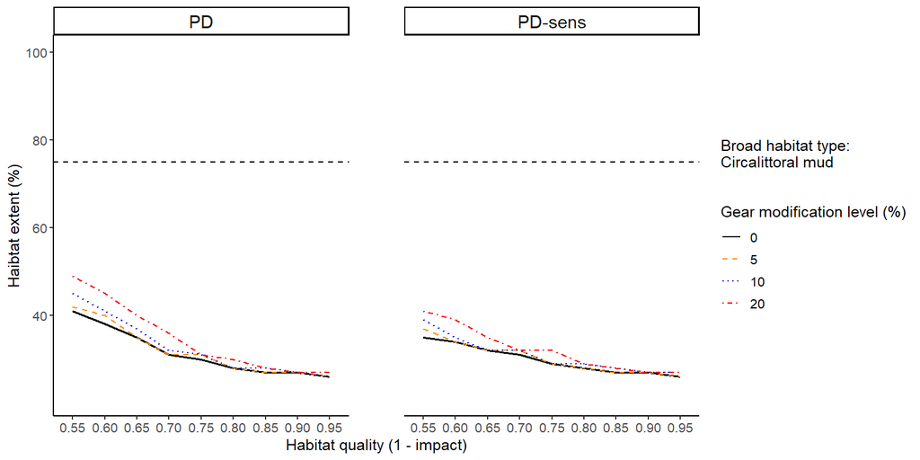

##### Figure 9: Habitat 2

**Figure 9. Effects of gear modifications (5%, 10%, and 20% lower depletion) on the quality-quantity threshold for the most abundant MSFD habitat type in the Gulf of Cadiz area. Habitat quality is defined as 1 - impact, with impact calculated as PD (I-6a) or PD-sens (I-7a). The dotted line represent the extent threshold of 75%.**

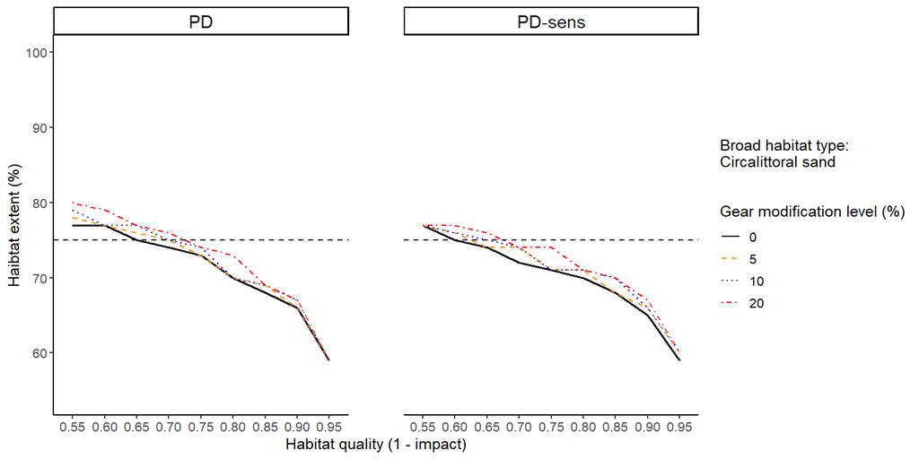

##### Figure 10: Habitat 3

**Figure 10. Effects of gear modifications (5%, 10%, and 20% lower depletion) on the quality-quantity threshold for the most abundant MSFD habitat type in the Gulf of Cadiz area. Habitat quality is defined as 1 - impact, with impact calculated as PD (I-6a) or PD-sens (I-7a). The dotted line represent the extent threshold of 75%.**

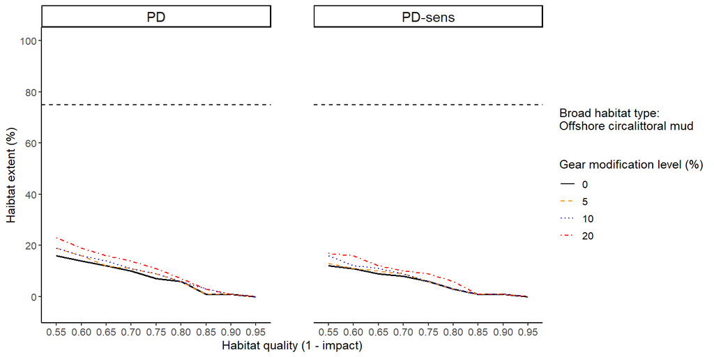

##### Figure 11: Habitat 4

**Figure 11. Effects of gear modifications (5%, 10%, and 20% lower depletion) on the quality-quantity threshold for the most abundant MSFD habitat type in the Gulf of Cadiz area. Habitat quality is defined as 1 - impact, with impact calculated as PD (I-6a) or PD-sens (I-7a). The dotted line represent the extent threshold of 75%.**

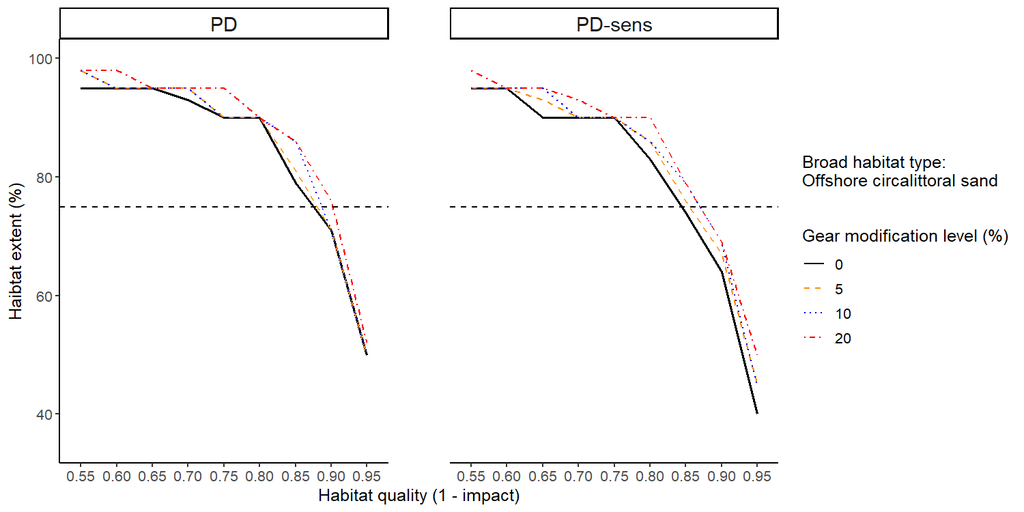

## Essential information

**Content of this advice product**

This document presents information on the distribution, intensity, impact, and economic value of mobile bottom-contacting gear (MBCG) fisheries within the Bay of Biscay and the Iberian Coast area, and estimated consequences and costs (landings weight and value) of reducing their relative extent. The information is from an assessment for the Bay of Biscay and the Iberian Coast area for the period 2017-2022. The six-year period was selected to include the latest available Vessel Monitoring System (VMS) and logbook data, rather than to match a specific Marine Strategy Framework Directive (MSFD) assessment period (EU, 2008).

The assessment describes fishing intensity and impact with five pressure indicators and four benthic impact indicators (Table E1).

**Table E1. Pressure and impact indicators that are applied by (sub-)regional and subdivision area, including the spatial scale and period over which the indicators are calculated.**

[output not shown]

For each defined assessment area and subdivision, tabs lead to ‘summary’ information and information on ‘fishing intensity’, ‘core fishing grounds’, ‘fishing by métier’, ‘impact’ and ‘scenarios’ (Table E2).

**Table E2. Information provided in the tabs for each assessment area.**

Tab

Description

Summary

- Values of pressure indicators I-1 to I-5 and impact indicators I-6a, I-6b, I-7a and I-7b by depth strata (Table 1).
- Maps of swept area ratio, median longevity of benthic fauna, and landings value and weight (Figure 1).
- Estimates of the contribution of small-scale fisheries (MBCG vessels <12m overall length) to total fishing effort in kW*fishing days (Table 2).

Fishing intensity

- The extent of broad habitat types, and various estimates of MBCG fishing activity for those habitat types; fisheries landings, value, and intensity (Table 3).
- Temporal variation of pressure indicators I-1, I-3 and I-4 (Figure 2).

Core fishing grounds

- Spatial stability of core fishing grounds (smallest area responsible for 90% of the landings value) over time (Figure 3) and their spatial distribution (Figure 4).

Fishing by métier

- Estimates of swept area, landings weight and landings value for the active métiers (Table 4).

Impact

- Spatial distribution of MBCG fisheries impact indicator values (I-6a) and (I-6b) (Figure 5).
- Temporal variation of impact indicators I-6a, I-6b, I-7a, and I-7b (Figure 6).
- Landings weight and value per unit impact for the active métiers (Table 5).
- Métier-specific impacts for the four most extensive broad habitat types (Figure 7).

Scenarios

- A ‘Footprint reduction’ scenario presenting effects of stepwise exclusion of MBCG fisheries in each broad habitat type, in terms of effort reduction (Table 6), landings value (Table 7), and landings weight (Table 8).
- A ‘Gear modifications’ scenario presenting the effects of gear modifications (assumed reduction in the depletion of benthic faunal biomass after a gear pass) on the quality-quantity threshold for the four most extensive habitat types (Figures 8-11).

**Data limitations in the Bay of Biscay and the Iberian Coast region**

**Figure E1. Map of the assessment area, showing the water depth class distributions (left), and boundaries of the relevant (MSFD) divisions and FAO rgeions (right).**

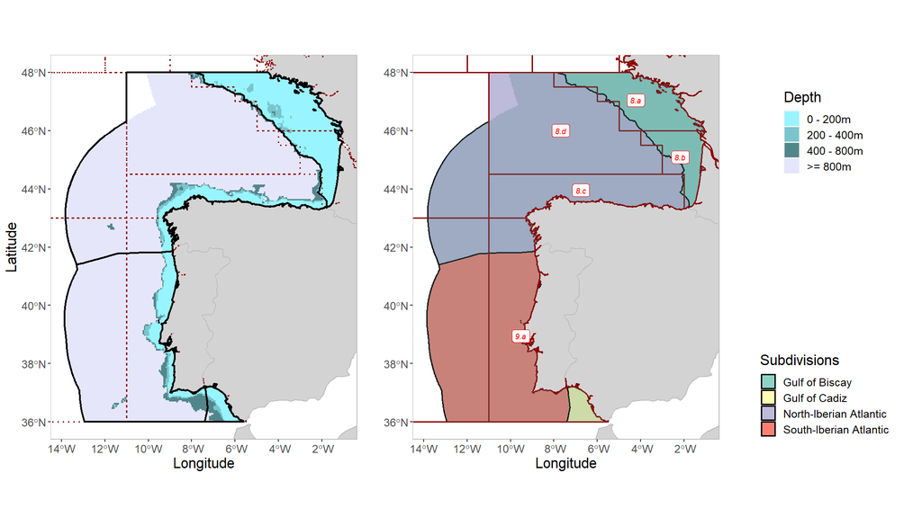

**How is fishing intensity evaluated?**

Five pressure indicators were used to describe fishing intensity and distribution resulting from the use of MBCG (Table E1). These indicators are calculated, for any given area as defined in this document, from estimates of the swept area in each of the c-squares within a defined area of interest. The swept area is calculated as hours fished × average fishing speed × gear width. This requires that VMS location records are linked to logbook data to associate a location and speed with gear code and fishing activity (Data Collection Framework level 4 and 6 respectively). VMS locations are allocated to ‘fishing’ and ‘not fishing’ based on vessel speed and other filters (ICES, 2022). The gear width is estimated based on relationships between average gear widths and average vessel length or engine power (kW) (Eigaard et al. 2016; ICES, 2022). The Swept Area Ratio (SAR) is calculated as the sum of the swept area attributed to all MBCG fishing recorded in the c-square within a year, divided by the area of that c-square. Therefore, the SAR indicates the theoretical number of times a c-square is swept per year, assuming that the MBCG fishing is evenly distributed over the c-square. For example, a SAR of 2 means that the entire c-square is fished 2 times over the year, a SAR of 0.5 means that the entire c-square is fished once in two years.

**How is benthic impact evaluated?**

Four indicators were used to describe benthic impacts. These indicators are generated from the assessment methods PD and PD-sens. PD (population dynamics method) is used to estimate the loss of benthic biomass, relative to carrying capacity, from a defined area if the current MBCG fishing intensity continues indefinitely (Pitcher et al., 2017, ICES 2018, 2022, Hiddink et al., 2019). PD-sens (population dynamics method for sensitive fauna) is used to estimate the loss of biomass of sensitive benthic fauna (the 10% most long-lived biomass fraction), relative to carrying capacity, from a defined area if the current MBCG fishing intensity continues indefinitely (ICES, 2024). For this advice, PD and PD-sens are estimated at the c-square scale.

**How are landings values evaluated?**

VMS location records are linked to logbook data to associate a location with gear code and fishing activity (Data Collection Framework level 4 and 6 respectively), and with landings weight and landings value records. VMS location records are classified as ‘fishing’ and ‘not fishing’ based on vessel speed and other filters (ICES, 2022). Landings weight and value are then allocated to the VMS location records classified as fishing, based on the time interval between location records or an equal split among location records by day, by ICES rectangle or by trip. Total landings weight or value by c-square, in a given time-interval, are calculated as the sum of the allocations to each location record in that c-square.

**References**

Eigaard O.R., Bastardie F., Breen M.l., Dinesen G.E., Lafargue P., Nielsen J.R., et al. 2016. Estimating seafloor pressure from trawls and dredges based on gear design and dimensions. ICES J. Mar. Sci. 73(1): 27-43 https://doi.org/10.1093/icesjms/fsv099

EU. 2008. Directive 2008/56/EC of the European Parliament and of the Council of 17 June 2008 establishing a framework for community action in the field of marine environmental policy (Marine Strategy Framework Directive) (Text with EEA relevance)

Hiddink, J. G., Jennings, S., Sciberras, M., Bolam, S. G., Cambiè, G., McConnaughey, R. A., Mazor, T., et al. 2019 Assessing bottom-trawling impacts based on the longevity of benthic invertebrates. Journal of Applied Ecology, 56: 1075–1083. https://doi.org/10.1111/1365-2664.13278.

ICES. 2018. Interim Report of the Working Group on Fisheries Benthic Impact and Trade-offs (WGFBIT), 12–16 November 2018, ICES Headquarters, Copenhagen, Denmark. ICES CM 2018/HAPISG:21. 74 pp.

ICES. 2022. Working Group on Fisheries Benthic Impact and Trade-offs (WGFBIT; outputs from 2021meeting). ICES Scientific Reports. 4:9. 133 pp. http://doi.org/10.17895/ices.pub.10042

Pitcher, C. R., Ellis, N., Jennings, S., Hiddink, J. G., Mazor, T., Kaiser, M. J., Kangas, M. I., et al. 2017. Estimating the sustainability of towed fishing-gear impacts on seabed habitats: a simple quantitative risk assessment method applicable to data-limited fisheries. Methods in Ecology and Evolution. 8: 472–480. https://doi.org/10.1111/2041-210X.12705.

Rijnsdorp, A. D., Bolam, S. G., Garcia, C., Hiddink, J. G., Hintzen, N. T., van Denderen, D. P., and Van Kooten, T. 2018. Estimating sensitivity of seabed habitats to disturbance by bottom trawling based on the longevity of benthic fauna. Ecological Applications, 28: 1302–1312. https://doi.org/10.1002/eap.1731

Rijnsdorp AD, Hiddink JG, van Denderen PD, Hintzen NT, Eigaard OR, Valanko S, Bastardie F, Bolam SG, Boulcott P, Egekvist J, Garcia C. 2020. Different bottom trawl fisheries have a differential impact on the status of the North Sea seafloor habitats. ICES Journal of Marine Science. 77(5): 1772-86. https://doi.org/10.1093/icesjms/fsaa050